# Lab 24: Chicago Crime Data I

## Instructions

Below you will find several empty R code scripts and answer prompts. Your task is to fill in the required code snippets and answer the corresponding questions.

## Chicago Crime Data

Today we are going to look at a fairly largerdataset. Each row of the data refers to a single reported crime in the City of Chicago:

The available variable are:

- `area_number`: the community area code of the crime; a number from 1-77
- `arrest_flag`: whether the crime resulted in an arrest; 0 is false and 1 is true
- `domestic_flag`: whether the crime is classified as a domestic offense; 0 is false and 1 is true
- `night_flag`: did the crime occur at night (9pm - 3am); 0 is false and 1 is true
- `burglary`: was the crime classified as a burglary? 0 is false and 1 is true
- `theft`: was the crime classified as a theft? 0 is false and 1 is true
- `battery`: was the crime classified as a battery? 0 is false and 1 is true
- `damage`: was the crime classified as a damage? 0 is false and 1 is true
- `assault`: was the crime classified as an assault? 0 is false and 1 is true
- `deception`: was the crime classified as criminal deception? 0 is false and 1 is true
- `robbery`: was the crime classified as a robbery? 0 is false and 1 is true
- `narcotics`: was the crime classified as a narcotics violation? 0 is false and 1 is true

We also have metadata about each community area within Chicago as well. We will see how to use these shortly.

- `area_number`: the community area code; a number from 1 to 77
- `area_name`: popular name of the community area
- `median_age`: the median age of all residents in the community area
- `num_households`: total number of households
- `family_households`: percentage of households classified as a `family’ (domestic partners, married couples, and one or more parents with children)
- `family_w_kids`: percentage of households with children under the age of 18
- `owner_ratio`: ratio of households that own or mortgage their primary residence
- `mean_travel_time`: average commute time
- `percent_walk`: percentage of commuters who walk to work (0-100)
- `median_income`: median household income
- `perc_20_units`: percentage of residential buildings with 20 or more units

It is difficult to do much of anything directly with the raw data. We need to utilize the group_summarize function to get somewhere interesting. Before doing that on the whole dataset, let’s make sure that we understand exactly what is going on by using the mean() and sum() functions directly. Take the mean of arrest_flag for the whole dataset:

```
## [1] 0.172482
```

Describe what this means in words.

Now, take the mean of the theft variable over the entire dataset:

```
## [1] 0.2751659
```

Describe what this means in words.

Take the sum of the theft variable:

```
## [1] 38816
```

Describe what this means in words.

**Answer**:This means that there are 38816 total thefts in the data set.

Take the dataset `ca` and calculate the sum of the variable `num_households`:

```
## [1] 1061928
```

Divide the answer to the previous question by the sum of the number of households variable and multiply by 1000.

```
## [1] 36.55238
```

Describe what this means in words.

Use the filter function to construct a dataset `temp` consisting only of those rows in `crimes` that come from area_number 23. This is the area named Humboldt Park.

```
## # A tibble: 4,191 x 12
##    area_number arrest_flag domestic_flag night_flag burglary theft battery
##          <int>       <int>         <int>      <int>    <int> <int>   <int>
##  1          23           0             0          1        0     0       0
##  2          23           0             0          1        0     1       0
##  3          23           0             0          1        0     0       0
##  4          23           0             0          1        0     0       0
##  5          23           0             0          0        0     1       0
##  6          23           1             1          1        0     0       0
##  7          23           0             0          1        1     0       0
##  8          23           0             0          1        0     1       0
##  9          23           0             0          1        0     0       0
## 10          23           0             0          1        0     1       0
## # ... with 4,181 more rows, and 5 more variables: damage <int>,
## #   assault <int>, deception <int>, robbery <int>, narcotics <int>
```

Take the mean of the variable arrests on the data `temp`.

```
## [1] 0.2569792
```

Is this smaller, larger, or about the same as the mean of the arrest flag over the entire dataset? Can we safely compare these measurements? If so describe the relationship in words.

Take the mean of the variable `theft` on the data `temp`.

```
## [1] 0.1877833
```

Is this smaller, larger, or about the same as the mean of the theft flag over the entire dataset? Can we safely compare these measurements? If so describe the relationship in words.

**Answer**:This is smaller than the mean over the entire dataset.

Manually look up the number of households in area 23, Humboldt Park, by looking at the dataset `ca` in the data viewer.

Take the sum of the number of thefts in temp, divide this by the number of households in Humboldt Park, and multiply by 1000:

```
## [1] 44.13909
```

Is this smaller, larger, or about the same as the same measurement over the over the entire dataset? Can we safely compare these measurements? If so describe the relationship in words.

**Answer**:This is larger than the thefts over the entire dataset. We can compare these measurements as the thefts over the entire data set in about 8 thefts less.

You have the tools to get the number of households in Humboldt Park entirely using R code. Specifically, filter `ca` to only include area 23 and then pull off `num_households` with the `$` operator. Try this here:

Now that we have an idea of what it means to take means and sums over this dataset, use `group_summarize` to summarize `crimes` at the community area level. Save the result as `crimes_ca`:

We want to combine the datasets `crimes_ca` and `ca`. To do this we use a new function `left_join`, as follows:

What variable is R using the match these datasets up?

**Answer**:area_number

By default, R will use any commonly named variables to match the datasets up. If we need it, I will show you how to modify this behavior later.

Construct a variable `theft_rate` equal to the number of thefts in each community area, divided by the number of households and multiplied by 1000.

Draw a scatter plot with median income on the x-axis and theft rate on the y-axis.

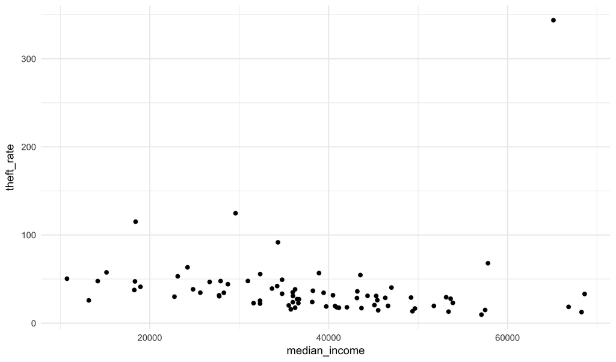

Describe the general pattern and any outliers.

**Answer**: In general the higher the median income the lower the theft rate. There is one oulier that has the highest theft rate and a very high median income.

Modify the previous plot so that the points are labeled with the area name:

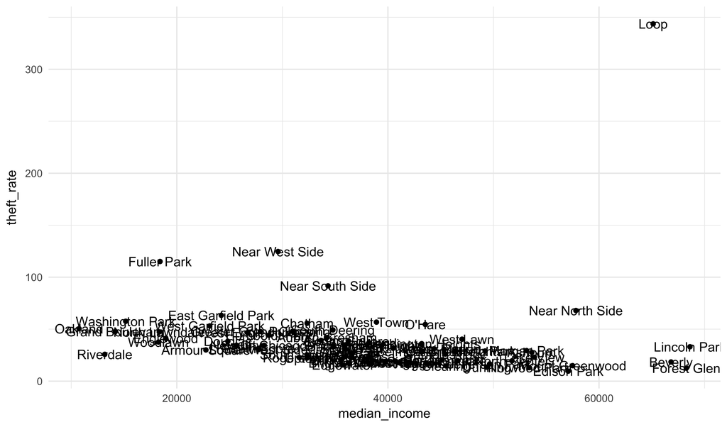

What is the name of the outlier?

**Answer**:Loop

(Critical Thinking) Look up the neighborhood that is the outlier on Wikipedia. Give an explanation for why this neighborhood has a high rate of theft per household. Hint: There are two distinct reasons.

**Answer**:The neighborhood has such a high crime rate due to it beinga high commercial zone that sees a lot of foot traffic.